# Machine Learning Mutual Fund Three Year Returns

##### Background

In this analysis we dive into a mutual funds data set scraped from Yahoo Finance in 2018. We analyze how different weightings of sectors could influence mutual fund returns for 3 year and 5 year annualized average returns. The data set contains 125 columns/variables, however many of these variables will be excluded from our analysis because they are either irrelevant (i.e inception date, fund name, fund family), or they are a function of fund returns and would thus be redundant correlations (i.e risk ratios like beta, alpha, sharpe). Some variables that would be of interest are predominantly weightings in sectors such stock, bonds, healthcare, technology, and etc. We will further reduce our variables to variables that have higher correlations with fund returns and then apply SVM (Support Vector Machines) to our features to predict if either (1) the fund has superior returns, meaning they return enough to beat the S&P500 including expenses (in this analysis we are only given information on expense ratios and no other fees such as "load" fees), and (0) the fund is non-superior, and do not beat the S&P 500.

###### Caution

Large assumptions are made for the sake of this project and may not reflect highly accurate on reality. (1) We assume that the portfolio weightings reported in 2018 do not change drastically over the 3 and 5 year time frame. For example if a mutual fund deploys a strategy of 60% tech, 20% healthcare, 10% utilities, 5% bonds, and 5% others, we will assume that mutual fund has held onto the strategy of higher weighting in tech and healthcare and did not drastically change in the last 3-5 years. (2) In reality many of these funds will have "load" fees, this can range from anywhere to 3-8%, for the case of this analysis we will assume a low end of 3% load fee is included for all mutual funds.

###### Labels

The labels that will be used are the "fund_return_3years" and "fund_return_5years." These are trailing average returns including dividends earned, for example 3 years will include returns from 2018, 2017, and 2016. We use these labels because it will evaluate the performance of the strategy employed in the last 3-5 years. ** CAUTION This conclusion would only be of use if an investor agrees with (1) the assumptions made priorly stated, and (2) that the strategy employed by the mutual funds will continue to be successful into the future

```python
import pandas as pd
import numpy as np
from matplotlib import pyplot as plt
import seaborn as sns
import warnings
warnings.filterwarnings("ignore")
%autosave 0
```

```
Autosave disabled
```

```python
df = pd.read_csv('mutual_funds.csv')
```

```python
dfcopy = df
```

```python
df.shape
```

```
(25308, 125)
```

```python
pd.set_option('display.max_columns', 500)
```

```python
df.head(5)
```

|  | fund_name | fund_extended_name | category | fund_family | net_assets | ytd_return | fund_yield | morningstar_rating | inception_date | investment | size | currency | net_annual_expense_ratio_fund | net_annual_expense_ratio_category | portfolio_cash | portfolio_stocks | portfolio_bonds | portfolio_others | portfolio_preferred | portfolio_convertable | price_earnings | price_book | price_sales | price_cashflow | median_market_cap | basic_materials | consumer_cyclical | financial_services | real_estate | … |
| --- | --- | --- | --- | --- | --- | --- | --- | --- | --- | --- | --- | --- | --- | --- | --- | --- | --- | --- | --- | --- | --- | --- | --- | --- | --- | --- | --- | --- | --- | --- |
| 0 | AAAAX | DWS RREEF Real Assets Fund - Class A | World Allocation | DWS | 5.302800e+08 | 12.79 | 1.43 | 3 | 7/29/2007 | Blend | Large | USD | 1.22 | 1.01 | 3.80 | 76.25 | 15.35 | 4.60 | 0.00 | 0.0 | 21.58 | 1.93 | 2.32 | 9.81 | 14,247.52 | 7.48 | 0.16 | 0.00 | 39.52 | … |
| 1 | AAADX | Aberdeen Income Builder Fund Class A | Large Blend | Aberdeen | 8.884000e+07 | 9.21 | 2.62 | 2 | 12/29/2011 | Blend | Large | USD | 1.43 | 0.94 | 1.97 | 47.13 | 49.75 | 0.00 | 1.14 | 0.0 | 11.76 | 2.94 | 2.81 | 13.6 | 147,673.66 | 0.00 | 4.78 | 17.68 | 1.15 | … |
| 2 | AAAGX | Thrivent Large Cap Growth Fund Class A | Large Growth | Thrivent Funds | 1.080000e+09 | 16.00 | 0.00 | 3 | 10/28/1999 | Growth | Large | USD | 1.15 | 1.06 | 1.91 | 97.06 | 0.00 | 1.03 | 0.00 | 0.0 | 24.49 | 5.78 | 4.45 | 14.29 | 156,593.77 | 0.00 | 20.20 | 16.12 | 0.00 | … |
| 3 | AAAIX | American Century Strategic Allocation: Aggress... | Allocation - 70% to 85% Equity | American Century Investments | 7.852700e+08 | 11.57 | 1.38 | 4 | 7/31/2000 | Growth | Large | USD | 0.91 | 0.77 | 2.57 | 75.06 | 22.29 | 0.04 | 0.00 | 0.0 | 15.92 | 2.02 | 1.5 | 6.12 | 34,965.16 | 2.37 | 14.71 | 16.03 | 5.43 | … |
| 4 | AAANX | Horizon Active Asset Allocation Fund Investor ... | Tactical Allocation | Horizon Investments | 5.271300e+08 | 11.62 | 0.66 | 4 | 1/30/2012 | Blend | Large | USD | 1.44 | 1.38 | 4.27 | 95.71 | 0.00 | 0.01 | 0.01 | 0.0 | 12.61 | 1.95 | 1.4 | 7.7 | 32,765.05 | 4.84 | 11.90 | 17.90 | 4.39 | … |

Here we will eliminate vairables that are not relevant to what we are looking to predict, which is 5 year and 3 year fund returns

```python
df = df[['net_assets', 'investment', 'size', 'net_annual_expense_ratio_fund', 'portfolio_cash', 'portfolio_stocks',
   'portfolio_bonds', 'portfolio_others', 'portfolio_preferred', 'portfolio_convertable', 'basic_materials',
    'consumer_cyclical', 'financial_services', 'real_estate', 'consumer_defensive', 'healthcare', 'utilities',
    'communication_services', 'energy', 'industrials', 'technology', 'fund_return_3years', 'fund_return_5years']]
```

```python
df.shape
```

```
(25308, 23)
```

```python
df.head()
```

|  | net_assets | investment | size | net_annual_expense_ratio_fund | portfolio_cash | portfolio_stocks | portfolio_bonds | portfolio_others | portfolio_preferred | portfolio_convertable | basic_materials | consumer_cyclical | financial_services | real_estate | consumer_defensive | healthcare | utilities | communication_services | energy | industrials | technology | fund_return_3years | fund_return_5years |
| --- | --- | --- | --- | --- | --- | --- | --- | --- | --- | --- | --- | --- | --- | --- | --- | --- | --- | --- | --- | --- | --- | --- | --- |
| 0 | 5.302800e+08 | Blend | Large | 1.22 | 3.80 | 76.25 | 15.35 | 4.60 | 0.00 | 0.0 | 7.48 | 0.16 | 0.00 | 39.52 | 0.93 | 0.00 | 19.56 | 5.02 | 17.03 | 9.24 | 1.08 | 7.10 | 2.94 |
| 1 | 8.884000e+07 | Blend | Large | 1.43 | 1.97 | 47.13 | 49.75 | 0.00 | 1.14 | 0.0 | 0.00 | 4.78 | 17.68 | 1.15 | 5.70 | 17.35 | 4.58 | 6.04 | 1.20 | 11.53 | 29.99 | 10.09 | 6.91 |
| 2 | 1.080000e+09 | Growth | Large | 1.15 | 1.91 | 97.06 | 0.00 | 1.03 | 0.00 | 0.0 | 0.00 | 20.20 | 16.12 | 0.00 | 3.99 | 16.52 | 0.00 | 0.00 | 0.78 | 7.08 | 35.30 | 15.39 | 12.00 |
| 3 | 7.852700e+08 | Growth | Large | 0.91 | 2.57 | 75.06 | 22.29 | 0.04 | 0.00 | 0.0 | 2.37 | 14.71 | 16.03 | 5.43 | 7.20 | 12.71 | 1.87 | 1.77 | 5.36 | 11.25 | 21.30 | 9.38 | 6.46 |
| 4 | 5.271300e+08 | Blend | Large | 1.44 | 4.27 | 95.71 | 0.00 | 0.01 | 0.01 | 0.0 | 4.84 | 11.90 | 17.90 | 4.39 | 7.36 | 11.23 | 3.97 | 3.70 | 5.56 | 10.53 | 18.61 | 9.24 | 5.77 |

```python
df.investment.unique()
```

```
array(['Blend', 'Growth', 'Value', nan], dtype=object)
```

```python
df['size'].unique()
```

```
array(['Large', 'Medium', 'Small', nan], dtype=object)
```

#### Will break investment style and size into "dummies"

##### Note will not use categoricals in SVM but still interesting to see for correlations

```python
df = pd.get_dummies(df, columns=['investment', 'size'])
```

```python
df.head()
```

|  | net_assets | net_annual_expense_ratio_fund | portfolio_cash | portfolio_stocks | portfolio_bonds | portfolio_others | portfolio_preferred | portfolio_convertable | basic_materials | consumer_cyclical | financial_services | real_estate | consumer_defensive | healthcare | utilities | communication_services | energy | industrials | technology | fund_return_3years | fund_return_5years | investment_Blend | investment_Growth | investment_Value | size_Large | size_Medium | size_Small |
| --- | --- | --- | --- | --- | --- | --- | --- | --- | --- | --- | --- | --- | --- | --- | --- | --- | --- | --- | --- | --- | --- | --- | --- | --- | --- | --- | --- |
| 0 | 5.302800e+08 | 1.22 | 3.80 | 76.25 | 15.35 | 4.60 | 0.00 | 0.0 | 7.48 | 0.16 | 0.00 | 39.52 | 0.93 | 0.00 | 19.56 | 5.02 | 17.03 | 9.24 | 1.08 | 7.10 | 2.94 | 1 | 0 | 0 | 1 | 0 | 0 |
| 1 | 8.884000e+07 | 1.43 | 1.97 | 47.13 | 49.75 | 0.00 | 1.14 | 0.0 | 0.00 | 4.78 | 17.68 | 1.15 | 5.70 | 17.35 | 4.58 | 6.04 | 1.20 | 11.53 | 29.99 | 10.09 | 6.91 | 1 | 0 | 0 | 1 | 0 | 0 |
| 2 | 1.080000e+09 | 1.15 | 1.91 | 97.06 | 0.00 | 1.03 | 0.00 | 0.0 | 0.00 | 20.20 | 16.12 | 0.00 | 3.99 | 16.52 | 0.00 | 0.00 | 0.78 | 7.08 | 35.30 | 15.39 | 12.00 | 0 | 1 | 0 | 1 | 0 | 0 |
| 3 | 7.852700e+08 | 0.91 | 2.57 | 75.06 | 22.29 | 0.04 | 0.00 | 0.0 | 2.37 | 14.71 | 16.03 | 5.43 | 7.20 | 12.71 | 1.87 | 1.77 | 5.36 | 11.25 | 21.30 | 9.38 | 6.46 | 0 | 1 | 0 | 1 | 0 | 0 |
| 4 | 5.271300e+08 | 1.44 | 4.27 | 95.71 | 0.00 | 0.01 | 0.01 | 0.0 | 4.84 | 11.90 | 17.90 | 4.39 | 7.36 | 11.23 | 3.97 | 3.70 | 5.56 | 10.53 | 18.61 | 9.24 | 5.77 | 1 | 0 | 0 | 1 | 0 | 0 |

```python
corr_matrix = (df.corr() > 0.2)
```

##### From the matrix we can see some corrleations with fund_return_3years

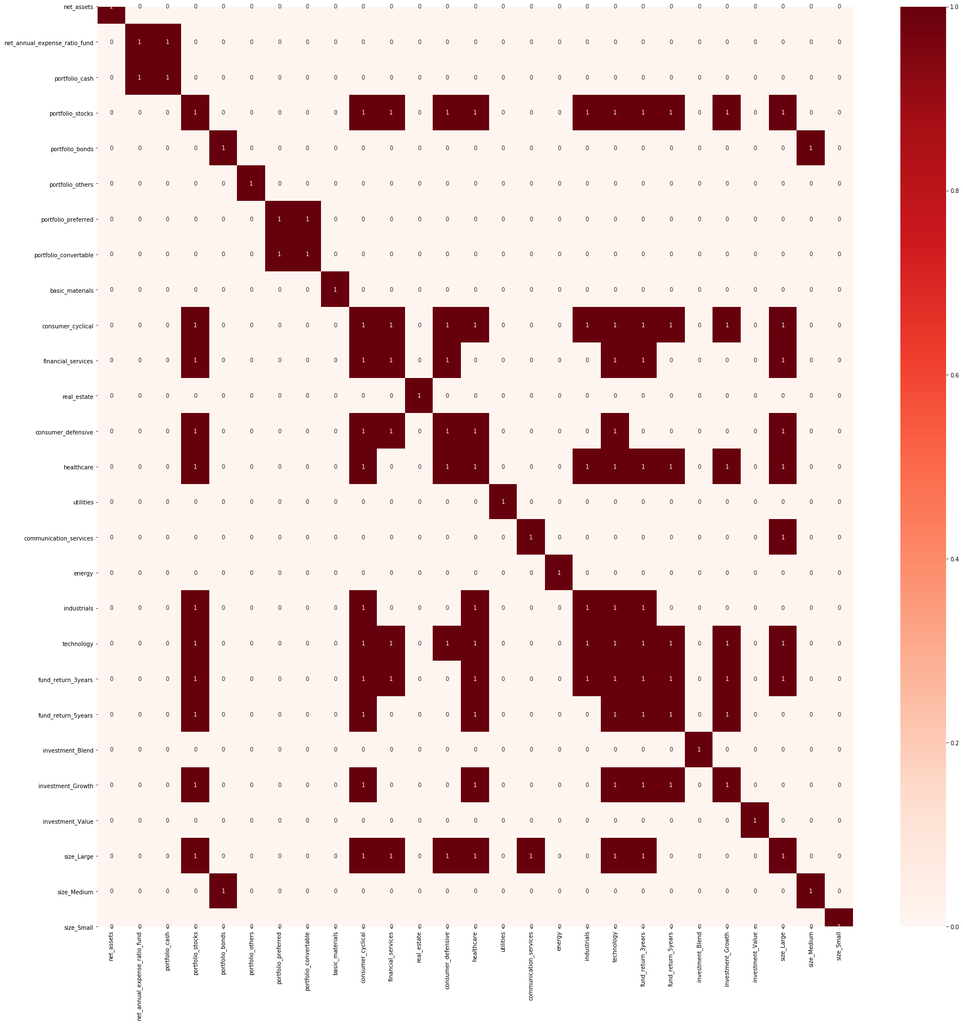

```python
plt.figure(figsize=(30,30))
sns.heatmap(corr_matrix, annot=True, cmap= "Reds")
```

```python
print("Top 15 Correlations for Fund Return 3 Years")
df[df.columns[0:]].corr()['fund_return_3years'][:].sort_values(ascending=False)[0:15]
```

```
Top 15 Correlations for Fund Return 3 Years
```

```
fund_return_3years        1.000000
fund_return_5years        0.781946
technology                0.619384
portfolio_stocks          0.573939
investment_Growth         0.412453
healthcare                0.407280
consumer_cyclical         0.325665
financial_services        0.239169
size_Large                0.229045
industrials               0.205804
consumer_defensive        0.164016
net_assets                0.078889
communication_services    0.056858
size_Small                0.023377
basic_materials           0.019410
Name: fund_return_3years, dtype: float64
```

#### Top Variables

We will first use the 7 top correlated variables

Fund 3 year Return: technology, portfolio_stocks, investment_growth (Note won't be used in SVM), healthcare, consumer_cylical, financial_services, and size_Large (will not be used in SVM)

### Making dtaframe for 3 Year Fund Return

```python
df3 = df[['fund_return_3years', 'technology', 'portfolio_stocks',
   'investment_Growth', 'consumer_cyclical', 'financial_services', 'size_Large', 'healthcare']]
```

```python
df3.head()
```

|  | fund_return_3years | technology | portfolio_stocks | investment_Growth | consumer_cyclical | financial_services | size_Large | healthcare |
| --- | --- | --- | --- | --- | --- | --- | --- | --- |
| 0 | 7.10 | 1.08 | 76.25 | 0 | 0.16 | 0.00 | 1 | 0.00 |
| 1 | 10.09 | 29.99 | 47.13 | 0 | 4.78 | 17.68 | 1 | 17.35 |
| 2 | 15.39 | 35.30 | 97.06 | 1 | 20.20 | 16.12 | 1 | 16.52 |
| 3 | 9.38 | 21.30 | 75.06 | 1 | 14.71 | 16.03 | 1 | 12.71 |
| 4 | 9.24 | 18.61 | 95.71 | 0 | 11.90 | 17.90 | 1 | 11.23 |

## Converting Three Year Return to Binary

1 = superior return

0 = non-superior

Need to make sure we have even distribution of both superior and non-superior

```
3 years fund return is 6.996638878964687
```

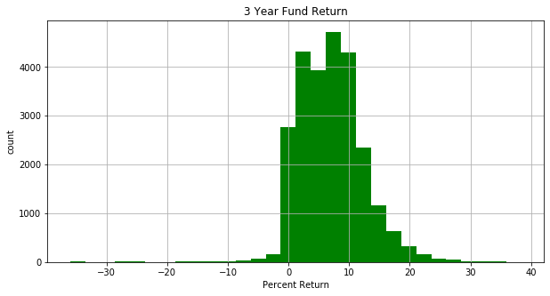

```python
df3.fund_return_3years.hist(figsize=(10,5), color='g', bins=30)
plt.title('3 Year Fund Return')
plt.xlabel('Percent Return')
plt.ylabel('count')

print("3 years fund return is", df3.fund_return_3years.mean())
```

However we still need to make the number classifications (1's = superior and 0's = non-superior) as evenly as possible, so we will have to pick at random <13% and number of data points equal to the number of data points above 13%

```python
dfcopy.net_annual_expense_ratio_fund.mean()
```

```
1.1218417101311984
```

```python
print("Number below 13% is", len(df3[df.fund_return_3years < 13]))
print("Number above 8.5% is", len(df3[df.fund_return_3years >= 13]))
```

```
Number below 13% is 22179
Number above 8.5% is 3012
```

```python
df3['return_binary'] = df3['fund_return_3years'].apply(lambda x: 1 if x >= 13 else 0)
```

```python
df3_0 = df3[df3.return_binary == 0]
df3_1 = df3[df3.return_binary == 1]
print(len(df3_0))
print(len(df3_1))
```

```
22296
3012
```

Need to calculate What percent to pick at random for df3_0 rows to match length of df3_1

```python
a = len(df3_1)/len(df3_0)
print(a)
```

```
0.13509149623250807
```

```python
print("We sample df3_0 at 13.5 percent to get %d random rows" %(len(df3_0.sample(frac=0.135))))
df3_0_sub = df3_0.sample(frac=0.135)
```

```
We sample df3_0 at 13.5 percent to get 3010 random rows
```

Now concatenate df_1 and df3_0_sub and shuffle

```python
df3 = pd.concat([df3_1, df3_0_sub], axis=0)
```

```python
df3 = df3.sample(frac=1, random_state= 42)
```

### Analyzing NA's

Three Year Fund Return

```python
print(df3.isna().sum())
print(df3.shape)
```

```
fund_return_3years    23
technology            19
portfolio_stocks      19
investment_Growth      0
consumer_cyclical     19
financial_services    19
size_Large             0
healthcare            19
return_binary          0
dtype: int64
(6022, 9)
```

```python
df3[df3.isna().any(axis=1)].head(15)
```

|  | fund_return_3years | technology | portfolio_stocks | investment_Growth | consumer_cyclical | financial_services | size_Large | healthcare | return_binary |
| --- | --- | --- | --- | --- | --- | --- | --- | --- | --- |
| 12064 | NaN | NaN | NaN | 0 | NaN | NaN | 1 | NaN | 0 |
| 8419 | NaN | NaN | NaN | 0 | NaN | NaN | 1 | NaN | 0 |
| 18383 | 0.81 | NaN | NaN | 1 | NaN | NaN | 0 | NaN | 0 |
| 20237 | 14.92 | NaN | NaN | 1 | NaN | NaN | 0 | NaN | 1 |
| 6017 | NaN | 0.00 | 98.76 | 0 | 1.79 | 0.00 | 0 | 0.00 | 0 |
| 12494 | NaN | 0.00 | 0.00 | 0 | 0.00 | 0.00 | 0 | 0.00 | 0 |
| 7413 | 0.94 | NaN | NaN | 0 | NaN | NaN | 1 | NaN | 0 |
| 14026 | NaN | NaN | NaN | 1 | NaN | NaN | 0 | NaN | 0 |
| 3860 | NaN | 24.90 | 100.00 | 1 | 23.77 | 7.55 | 1 | 7.87 | 0 |
| 2114 | 19.81 | NaN | NaN | 1 | NaN | NaN | 1 | NaN | 1 |
| 23438 | NaN | NaN | NaN | 0 | NaN | NaN | 1 | NaN | 0 |
| 9103 | NaN | NaN | NaN | 0 | NaN | NaN | 0 | NaN | 0 |
| 6818 | NaN | NaN | NaN | 1 | NaN | NaN | 1 | NaN | 0 |
| 3596 | NaN | NaN | NaN | 0 | NaN | NaN | 0 | NaN | 0 |
| 15236 | NaN | 16.14 | 33.38 | 0 | 13.32 | 17.11 | 1 | 10.81 | 0 |

###### Looking at NA's in more depth you can see that there is significant overlap with all the variables. In this case, and since the number of NA's is such a small percentage of the data set, it makes no sense to impute the median and will thus drop all NA's

```python
df3.shape
```

```
(6022, 9)
```

```python
df3.dropna(inplace=True)
print("new RowsxCol's is", df3.shape)
```

```
new RowsxCol's is (5996, 9)
```

```python
percentdrop = (6022-len(df3))/6022*100
print('Dropped %0.2f percent of the rows in the dataset' %percentdrop)
```

```
Dropped 0.43 percent of the rows in the dataset
```

### Outliers

```python
df3.columns
```

```
Index(['fund_return_3years', 'technology', 'portfolio_stocks',
       'investment_Growth', 'consumer_cyclical', 'financial_services',
       'size_Large', 'healthcare', 'return_binary'],
      dtype='object')
```

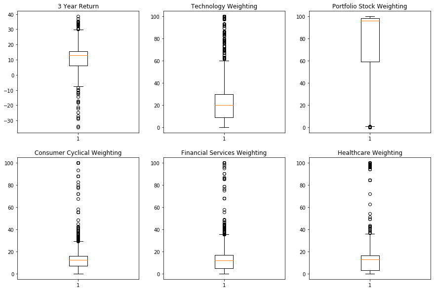

```python
# Multiple Boxplots
import seaborn as sns
fig, axs = plt.subplots(2, 3, figsize=(15, 10))

axs[0, 0].boxplot(df3.fund_return_3years)
axs[0, 0].set_title('3 Year Return')
axs[0, 1].boxplot(df3.technology)
axs[0, 1].set_title('Technology Weighting')
axs[0, 2].boxplot(df3.portfolio_stocks)
axs[0, 2].set_title('Portfolio Stock Weighting')
axs[1, 0].boxplot(df3.consumer_cyclical)
axs[1, 0].set_title('Consumer Cyclical Weighting')
axs[1, 1].boxplot(df3.financial_services)
axs[1, 1].set_title('Financial Services Weighting')
axs[1, 2].boxplot(df3.healthcare)
axs[1, 2].set_title('Healthcare Weighting')
```

```python
df3.describe()
```

[output not shown]

Fund Returns Data: since very high returns are a needle in a haystack and are usually for 1% net worth investors, we will get rid of anything over 30% return. We will also get rid of returns <20%, or, very poor performance since this is unusual for a mutual fund to stay in business and perform so badly.

It would also make sense that an investor may want to invest in a mutual fund that is at least somewhat diversified, even if it is just a little. Thus we will drop funds that are over 90% weighting in an individual sector

```python
a = df3[df3.healthcare >= 90]['healthcare'].count()
print("There %d data points in healthcare above 90 percent" %a)
b = df3[df3.technology >= 90]['technology'].count()
print("There %d data points in technology above 90 percent" %b)
a = df3[df3.consumer_cyclical >= 90]['consumer_cyclical'].count()
print("There %d data points in Consumer Cyclical above 90 percent" %a)
b = df3[df3.financial_services >= 90]['financial_services'].count()
print("There %d data points in Financial Services above 90 percent" %b)
```

```
There 48 data points in healthcare above 90 percent
There 33 data points in technology above 90 percent
There 12 data points in Consumer Cyclical above 90 percent
There 25 data points in Financial Services above 90 percent
```

We will exclude those data points in our analysis

```python
df3 = df3[(df3.technology <= 90) & (df3.healthcare <= 90) & (df3.consumer_cyclical <= 90) & (df3.financial_services <= 90)]
df3.shape
```

```
(5880, 9)
```

```python
df3 = df3[(df.fund_return_3years >= -20) & (df3.fund_return_3years <= 30)]
print(df3.shape)
```

```
(5858, 9)
```

### Scale/Normalize

###### 3 Year Return

```python
df3.agg(['mean', 'max', 'min'])
```

|  | fund_return_3years | technology | portfolio_stocks | investment_Growth | consumer_cyclical | financial_services | size_Large | healthcare | return_binary |
| --- | --- | --- | --- | --- | --- | --- | --- | --- | --- |
| mean | 11.045292 | 20.089397 | 74.378126 | 0.503585 | 11.491931 | 11.650722 | 0.600205 | 11.124222 | 0.496927 |
| max | 29.710000 | 89.630000 | 100.000000 | 1.000000 | 87.870000 | 90.000000 | 1.000000 | 84.560000 | 1.000000 |
| min | -15.810000 | 0.000000 | 0.000000 | 0.000000 | 0.000000 | 0.000000 | 0.000000 | 0.000000 | 0.000000 |

Dropping catrgoricals for SVM

```python
df3_copy = df3.copy() #for KNN latter on
df3_copy.head()
```

|  | fund_return_3years | technology | portfolio_stocks | investment_Growth | consumer_cyclical | financial_services | size_Large | healthcare | return_binary |
| --- | --- | --- | --- | --- | --- | --- | --- | --- | --- |
| 17112 | 16.90 | 24.49 | 97.60 | 1 | 17.38 | 8.12 | 0 | 16.41 | 1 |
| 9696 | 16.64 | 31.17 | 98.94 | 1 | 16.54 | 6.24 | 0 | 16.53 | 1 |
| 10707 | 16.21 | 35.99 | 98.76 | 1 | 17.04 | 9.55 | 1 | 14.29 | 1 |
| 15038 | 23.69 | 69.68 | 98.49 | 1 | 9.80 | 1.69 | 0 | 12.40 | 1 |
| 22721 | 5.15 | 13.91 | 96.77 | 0 | 4.10 | 23.82 | 1 | 13.64 | 0 |

```python
df3.drop(columns=['size_Large', 'investment_Growth'], inplace=True)
```

When looking at all the variables we can see the value ranges are all fairly different. We must normalize all the values.

```python
#Will drop the Target (Return_binary before scaleing)
Y = df3[['return_binary']]
df3.drop('return_binary', axis=1, inplace=True)
```

```python
import sklearn
from sklearn import preprocessing
df3_scale = preprocessing.MinMaxScaler().fit_transform(df3)
```

```python
df3_scale
```

```
array([[0.71858524, 0.27323441, 0.976     , 0.19779219, 0.09022222,
        0.19406339],
       [0.71287346, 0.34776303, 0.9894    , 0.18823262, 0.06933333,
        0.1954825 ],
       [0.70342707, 0.40153966, 0.9876    , 0.19392284, 0.10611111,
        0.16899243],
       ...,
       [0.44551845, 0.01249582, 0.9682    , 0.00990099, 0.        ,
        0.        ],
       [0.60061511, 0.24456097, 0.8322    , 0.142028  , 0.14866667,
        0.19075213],
       [0.63532513, 0.18297445, 0.9901    , 0.09092978, 0.03811111,
        0.22634816]])
```

```python
#Note we won't include numerical 3 year return
df3_scale_df = pd.DataFrame({'consumer_cyclical': df3_scale[:,1],
                             'technology': df3_scale[:,2], 'portfolio_stocks': df3_scale[:,3], 'financial_services': df3_scale[:,4],
                             'healthcare': df3_scale[:,5]})
df3_scale_df.head(5)
```

|  | consumer_cyclical | technology | portfolio_stocks | financial_services | healthcare |
| --- | --- | --- | --- | --- | --- |
| 0 | 0.273234 | 0.9760 | 0.197792 | 0.090222 | 0.194063 |
| 1 | 0.347763 | 0.9894 | 0.188233 | 0.069333 | 0.195482 |
| 2 | 0.401540 | 0.9876 | 0.193923 | 0.106111 | 0.168992 |
| 3 | 0.777418 | 0.9849 | 0.111528 | 0.018778 | 0.146641 |
| 4 | 0.155194 | 0.9677 | 0.046660 | 0.264667 | 0.161306 |

```python
df3_scale_df = df3_scale_df.merge(Y, on=df3_scale_df.index)
```

```python
df3_scale_df.drop('key_0', axis=1, inplace=True)
df3_scale_copy = df3_scale_df.copy()
```

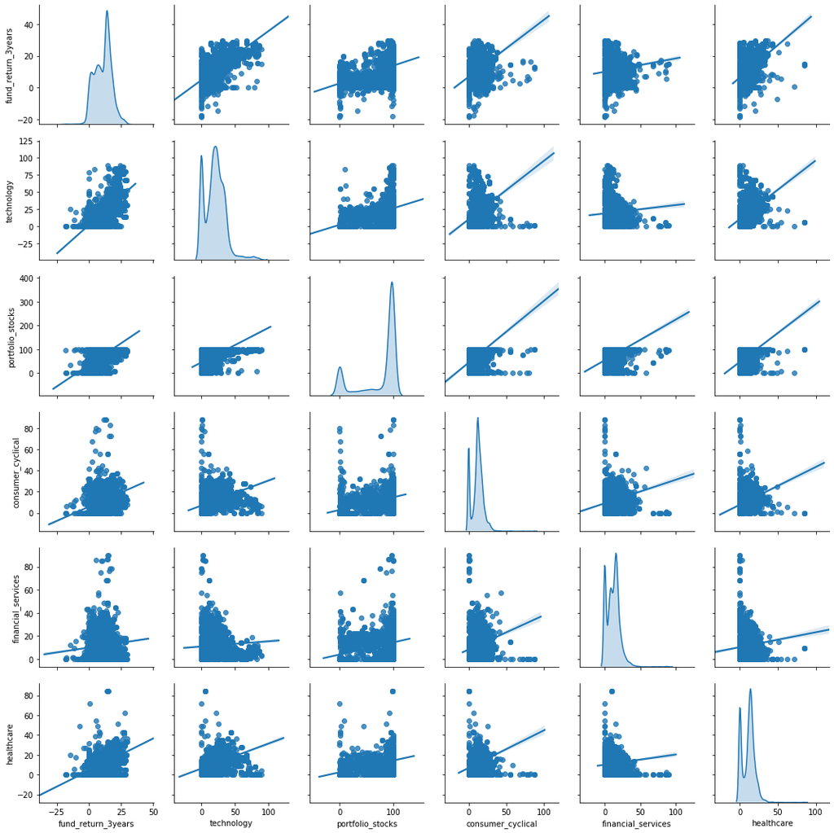

```python
sns.pairplot(df3, diag_kind='kde', kind='reg')
```

###### Break df3_scale_df into training and testing data

```python
Y = df3_scale_df[['return_binary']]
Y = Y.astype('int')
df3_scale_df.drop('return_binary', axis=1, inplace=True)
```

```python
X = df3_scale_df
X.head()
```

|  | consumer_cyclical | technology | portfolio_stocks | financial_services | healthcare |
| --- | --- | --- | --- | --- | --- |
| 0 | 0.273234 | 0.9760 | 0.197792 | 0.090222 | 0.194063 |
| 1 | 0.347763 | 0.9894 | 0.188233 | 0.069333 | 0.195482 |
| 2 | 0.401540 | 0.9876 | 0.193923 | 0.106111 | 0.168992 |
| 3 | 0.777418 | 0.9849 | 0.111528 | 0.018778 | 0.146641 |
| 4 | 0.155194 | 0.9677 | 0.046660 | 0.264667 | 0.161306 |

```python
from sklearn.model_selection import train_test_split
X_train, X_test, Y_train, Y_test = train_test_split(X, Y, test_size = 0.3, random_state = 0)
```

```python
#Confirmation
len(X_train)/(len(X_train) + len(X_test))
```

```
0.699897575964493
```

## SVM (Support Vector Machine)

```python
from sklearn import svm
from sklearn.svm import SVC
```

```python
clf = svm.SVC(kernel = 'linear')
clf.fit(X_train, Y_train)
```

```
SVC(C=1.0, cache_size=200, class_weight=None, coef0=0.0,
    decision_function_shape='ovr', degree=3, gamma='auto_deprecated',
    kernel='linear', max_iter=-1, probability=False, random_state=None,
    shrinking=True, tol=0.001, verbose=False)
```

```python
y_pred = clf.predict(X_test)
```

```python
from sklearn import metrics
print("Metrics for SVM 3 Year Returns model are:")
print()
print("Accuracy:", metrics.accuracy_score(Y_test, y_pred))
print("Precision:", metrics.precision_score(Y_test, y_pred))
print("Recall:", metrics.recall_score(Y_test, y_pred))
print('AUC score is:', metrics.roc_auc_score(Y_test, y_pred))
```

```
Metrics for SVM 3 Year Returns model are:

Accuracy: 0.8589306029579067
Precision: 0.8597914252607184
Recall: 0.85385500575374
AUC score is: 0.8588735096260263
```

```python
df3_scale_df.head(1)
```

|  | consumer_cyclical | technology | portfolio_stocks | financial_services | healthcare |
| --- | --- | --- | --- | --- | --- |
| 0 | 0.273234 | 0.976 | 0.197792 | 0.090222 | 0.194063 |

```python
#### Example prediction [consumer_cyclical, technology, portfolio_stocks, financial_services, healthcare]
clf.predict([[.22, 0.78, 0.45, 0.10, 0.34]])
```

```
array([1])
```

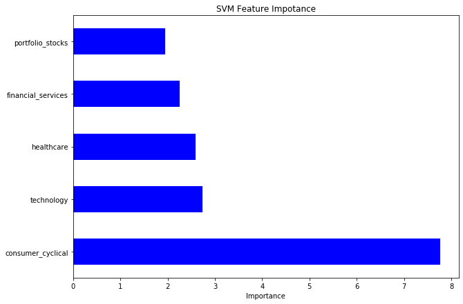

```python
pd.Series(abs(clf.coef_[0]), index=df3_scale_df.columns).nlargest(10).plot(kind='barh', figsize=(10,7), color='b')
plt.title('SVM Feature Impotance')
plt.xlabel('Importance')
```

##### Analyzing distributions of top 5 features

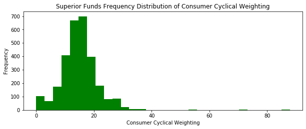

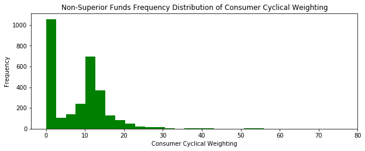

```python
plt.subplot(2, 1, 1)
df3_copy[df3_copy.return_binary == 1]['consumer_cyclical'].plot(kind="hist", color='green', bins=30, figsize=(10,8))
plt.title('Superior Funds Frequency Distribution of Consumer Cyclical Weighting')
plt.xlabel('Consumer Cyclical Weighting')
plt.show()

plt.subplot(2, 1, 2)
df3_copy[df3_copy.return_binary == 0]['consumer_cyclical'].plot(kind="hist", color='green', bins=30, figsize=(10,8))
plt.title('Non-Superior Funds Frequency Distribution of Consumer Cyclical Weighting')
plt.xlabel('Consumer Cyclical Weighting')
plt.show()
```

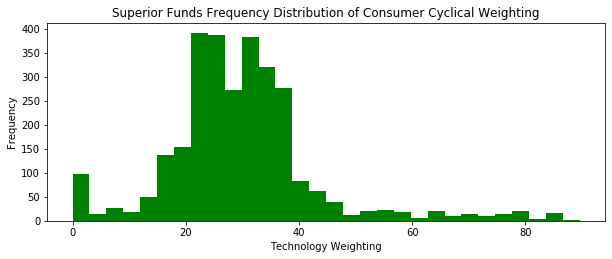

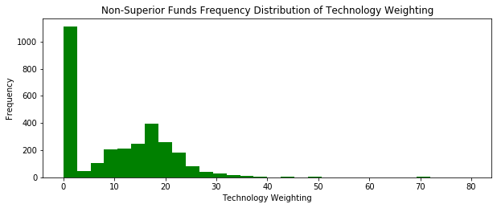

```python
plt.subplot(2, 1, 1)
df3_copy[df3_copy.return_binary == 1]['technology'].plot(kind="hist", color='green', bins=30, figsize=(10,8))
plt.title('Superior Funds Frequency Distribution of Consumer Cyclical Weighting')
plt.xlabel('Technology Weighting')
plt.show()

plt.subplot(2, 1, 2)
df3_copy[df3_copy.return_binary == 0]['technology'].plot(kind="hist", color='green', bins=30, figsize=(10,8))
plt.title('Non-Superior Funds Frequency Distribution of Technology Weighting')
plt.xlabel('Technology Weighting')
plt.show()
```

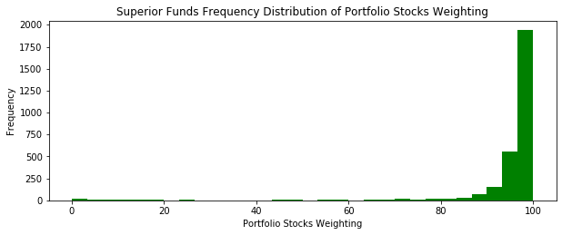

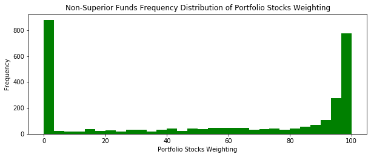

```python
plt.subplot(2, 1, 1)
df3_copy[df3_copy.return_binary == 1]['portfolio_stocks'].plot(kind="hist", color='green', bins=30, figsize=(10,8))
plt.title('Superior Funds Frequency Distribution of Portfolio Stocks Weighting')
plt.xlabel('Portfolio Stocks Weighting')
plt.show()

plt.subplot(2, 1, 2)
df3_copy[df3_copy.return_binary == 0]['portfolio_stocks'].plot(kind="hist", color='green', bins=30, figsize=(10,8))
plt.title('Non-Superior Funds Frequency Distribution of Portfolio Stocks Weighting')
plt.xlabel('Portfolio Stocks Weighting')
plt.show()
```

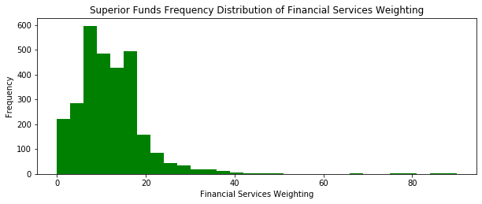

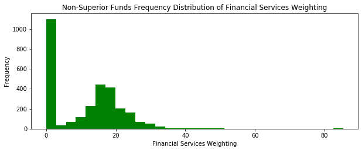

```python
plt.subplot(2, 1, 1)
df3_copy[df3_copy.return_binary == 1]['financial_services'].plot(kind="hist", color='green', bins=30, figsize=(10,8))
plt.title('Superior Funds Frequency Distribution of Financial Services Weighting')
plt.xlabel('Financial Services Weighting')
plt.show()

plt.subplot(2, 1, 2)
df3_copy[df3_copy.return_binary == 0]['financial_services'].plot(kind="hist", color='green', bins=30, figsize=(10,8))
plt.title('Non-Superior Funds Frequency Distribution of Financial Services Weighting')
plt.xlabel('Financial Services Weighting')
plt.show()
```

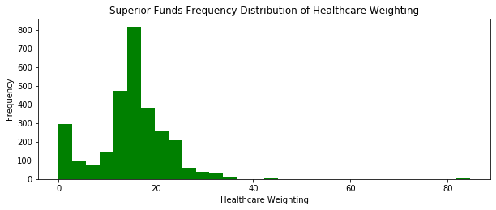

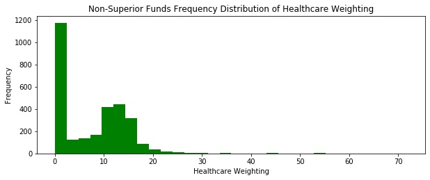

```python
plt.subplot(2, 1, 1)
df3_copy[df3_copy.return_binary == 1]['healthcare'].plot(kind="hist", color='green', bins=30, figsize=(10,8))
plt.title('Superior Funds Frequency Distribution of Healthcare Weighting')
plt.xlabel('Healthcare Weighting')
plt.show()

plt.subplot(2, 1, 2)
df3_copy[df3_copy.return_binary == 0]['healthcare'].plot(kind="hist", color='green', bins=30, figsize=(10,8))
plt.title('Non-Superior Funds Frequency Distribution of Healthcare Weighting')
plt.xlabel('Healthcare Weighting')
plt.show()
```

For this next analysis I will select 2 of the top 3 most impactful features to model and focus on in hopes to improve accuracy

### C Grid Search

From sklearn library we can utilize a GridSearchCV paramter for SVM. We can find what is the optimal C value as well and type of kernel and gamma parameter

```python
from sklearn.model_selection import GridSearchCV
parameters = {'kernel':('linear', 'rbf'), 'C':[0.1, 0.5, 1, 2, 3, 4, 5, 10],
             'gamma':[1e-3, 1e-4, 1e-5, 0.01, 0.1, 1, 2, 3, 10]}
```

```python
from sklearn import svm
from sklearn.svm import SVC
sv5 = svm.SVC()
```

```python
clfsv = GridSearchCV(sv5, parameters)
clfsv.fit(X_train, Y_train)
```

```
GridSearchCV(cv='warn', error_score='raise-deprecating',
             estimator=SVC(C=1.0, cache_size=200, class_weight=None, coef0=0.0,
                           decision_function_shape='ovr', degree=3,
                           gamma='auto_deprecated', kernel='rbf', max_iter=-1,
                           probability=False, random_state=None, shrinking=True,
                           tol=0.001, verbose=False),
             iid='warn', n_jobs=None,
             param_grid={'C': [0.1, 0.5, 1, 2, 3, 4, 5, 10],
                         'gamma': [0.001, 0.0001, 1e-05, 0.01, 0.1, 1, 2, 3,
                                   10],
                         'kernel': ('linear', 'rbf')},
             pre_dispatch='2*n_jobs', refit=True, return_train_score=False,
             scoring=None, verbose=0)
```

```python
print(clfsv.best_params_)
```

```
{'C': 10, 'gamma': 3, 'kernel': 'rbf'}
```

```python
sv5 = svm.SVC(kernel='rbf', C = 10, gamma = 3)
sv5.fit(X_train, Y_train)
y_pred = sv5.predict(X_test)
print("Metrics for C = 10, kernel = rbf, gamma = 3")
print()
print("Accuracy:", metrics.accuracy_score(Y_test, y_pred))
print("Precision:", metrics.precision_score(Y_test, y_pred))
print("Recall:",metrics.recall_score(Y_test, y_pred))
print('AUC score is:', metrics.roc_auc_score(Y_test, y_pred))
```

```
Metrics for C = 10, kernel = rbf, gamma = 3

Accuracy: 0.8805460750853242
Precision: 0.8731596828992072
Recall: 0.8872266973532796
AUC score is: 0.8806212226923879
```

The C grid serach was able to optimize C, gamma, and type of kernel that led to higher Accuracy, Precision, Recall, and AUC Scores! Based on some of the lop-sided distribtuions of some the features and number of features in the model, I am not surprised C grid serach picked a radial ('rbf') kerne.

For experimental and display purposes, SVM will be ran on the top two most impactful features, consumer_cyclical and technology

### Analysis of SVM with Top 2 Feature Importances

```python
df3_2feat = df3_scale_df[['consumer_cyclical', 'technology']]
```

```python
y = Y['return_binary']
y = y.astype('int')
x = df3_2feat
```

```python
from sklearn.model_selection import train_test_split
x_train, x_test, y_train, y_test = train_test_split(x, y, test_size = 0.3, random_state = 0)
```

```python
#code privded by https://jakevdp.github.io/PythonDataScienceHandbook/05.07-support-vector-machines.html
def plot_svc_decision_function(model, ax=None, plot_support=True):
    """Plot the decision function for a 2D SVC"""
    if ax is None:
        ax = plt.gca()
    xlim = ax.get_xlim()
    ylim = ax.get_ylim()

    # create grid to evaluate model
    x = np.linspace(xlim[0], xlim[1], 30)
    y = np.linspace(ylim[0], ylim[1], 30)
    Y, X = np.meshgrid(y, x)
    xy = np.vstack([X.ravel(), Y.ravel()]).T
    P = model.decision_function(xy).reshape(X.shape)

    # plot decision boundary and margins
    ax.contour(X, Y, P, colors='k',
               levels=[-1, 0, 1], alpha=0.5,
               linestyles=['--', '-', '--'])

    # plot support vectors
    if plot_support:
        ax.scatter(model.support_vectors_[:, 0],
                   model.support_vectors_[:, 1],
                   s=300, linewidth=1, facecolors='none');
    ax.set_xlim(xlim)
    ax.set_ylim(ylim)
```

```python
x_test = np.array(x_test)
y_test = np.array(y_test)
x_train = np.array(x_train)
y_train = np.array(y_train)
```

###### Note

We want to analyze various C values at first glance to see how we can tweak and improve our model by increasing or decreasing C

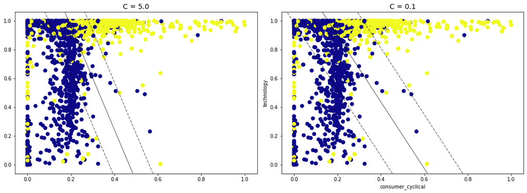

```python
#code privded by https://jakevdp.github.io/PythonDataScienceHandbook/05.07-support-vector-machines.html
fig, ax = plt.subplots(1, 2, figsize=(16, 6))
fig.subplots_adjust(left=0.0625, right=0.95, wspace=0.1)

for axi, C in zip(ax, [5.0, 0.1]):
    model = SVC(kernel='linear', C=C).fit(x_train, y_train)
    axi.scatter(x_train[:, 0], x_train[:, 1], c=y_train, s=50, cmap='plasma')
    plot_svc_decision_function(model, axi)
    axi.scatter(model.support_vectors_[:, 0],
                model.support_vectors_[:, 1],
                s=300, lw=1, facecolors='none');
    axi.set_title('C = {0:.1f}'.format(C), size=14)
plt.ylabel('technology')
plt.xlabel('consumer_cyclical')
```

```python
sv = svm.SVC(kernel = 'linear', C=5)
sv.fit(x_train, y_train)
```

```
SVC(C=5, cache_size=200, class_weight=None, coef0=0.0,
    decision_function_shape='ovr', degree=3, gamma='auto_deprecated',
    kernel='linear', max_iter=-1, probability=False, random_state=None,
    shrinking=True, tol=0.001, verbose=False)
```

```python
y_pred = sv.predict(x_test)
```

```python
print("Metrics for C = 5")
print()
print("Accuracy:", metrics.accuracy_score(y_test, y_pred))
print("Precision:", metrics.precision_score(y_test, y_pred))
print("Recall:",metrics.recall_score(y_test, y_pred))
print('AUC score is:', metrics.roc_auc_score(y_test, y_pred))
```

```
Metrics for C = 5

Accuracy: 0.863481228668942
Precision: 0.8482834994462901
Recall: 0.8814729574223246
AUC score is: 0.8636836103197112
```

```python
svm2 = svm.SVC(kernel = 'linear', C=0.1)
svm2.fit(x_train, y_train)
```

```
SVC(C=0.1, cache_size=200, class_weight=None, coef0=0.0,
    decision_function_shape='ovr', degree=3, gamma='auto_deprecated',
    kernel='linear', max_iter=-1, probability=False, random_state=None,
    shrinking=True, tol=0.001, verbose=False)
```

```python
y_pred = svm2.predict(x_test)
```

```python
print("Metrics for C = 0.1")
print()
print("Accuracy:", metrics.accuracy_score(y_test, y_pred))
print("Precision:", metrics.precision_score(y_test, y_pred))
print("Recall:",metrics.recall_score(y_test, y_pred))
print('AUC score is:', metrics.roc_auc_score(y_test, y_pred))
```

```
Metrics for C = 0.1

Accuracy: 0.8577929465301479
Precision: 0.8207253886010363
Recall: 0.9113924050632911
AUC score is: 0.8583958650738278
```

### C Grid Search Fine Tunning On Top Two Features

```python
from sklearn import svm
from sklearn.svm import SVC
svc = svm.SVC()
```

```python
clf = GridSearchCV(svc, parameters)
clf.fit(x_train, y_train)
```

```
GridSearchCV(cv='warn', error_score='raise-deprecating',
             estimator=SVC(C=1.0, cache_size=200, class_weight=None, coef0=0.0,
                           decision_function_shape='ovr', degree=3,
                           gamma='auto_deprecated', kernel='rbf', max_iter=-1,
                           probability=False, random_state=None, shrinking=True,
                           tol=0.001, verbose=False),
             iid='warn', n_jobs=None,
             param_grid={'C': [0.1, 0.5, 1, 2, 3, 4, 5, 10],
                         'gamma': [0.001, 0.0001, 1e-05, 0.01, 0.1, 1, 2, 3,
                                   10],
                         'kernel': ('linear', 'rbf')},
             pre_dispatch='2*n_jobs', refit=True, return_train_score=False,
             scoring=None, verbose=0)
```

```python
print(clf.best_params_)
```

```
{'C': 4, 'gamma': 2, 'kernel': 'rbf'}
```

[figure not shown]

```python
#code privded by https://jakevdp.github.io/PythonDataScienceHandbook/05.07-support-vector-machines.html
fig, ax = plt.subplots(1, 2, figsize=(16, 6))
fig.subplots_adjust(left=0.0625, right=0.95, wspace=0.1)

for axi, C in zip(ax, [4,0.1]):
    model = SVC(kernel='rbf', C=C, gamma = 2).fit(x_train, y_train)
    axi.scatter(x_train[:, 0], x_train[:, 1], c=y_train, s=50, cmap='plasma')
    plot_svc_decision_function(model, axi)
    axi.scatter(model.support_vectors_[:, 0],
                model.support_vectors_[:, 1],
                s=300, lw=1, facecolors='none');
    axi.set_title('C = {0:.1f}'.format(C), size=14)

plt.ylabel('technology')
plt.xlabel('consumer_cyclical')
```

```python
from sklearn import svm
from sklearn.svm import SVC
svc = svm.SVC(kernel='rbf', C = 4, gamma = 2)
svc.fit(x_train, y_train)
y_pred = svc.predict(x_test)
```

```python
print("Metrics for C = 4, kernel = rbf, and gamma = 2")
print()
print("Accuracy:", metrics.accuracy_score(y_test, y_pred))
print("Precision:", metrics.precision_score(y_test, y_pred))
print("Recall:", metrics.recall_score(y_test, y_pred))
print('AUC score is:', metrics.roc_auc_score(y_test, y_pred))
```

[output not shown]

The C grid search was able to select a C = 4, kernel = rbf, and gamma = 2 that increased Recall. I would say this is not as good as the optimized 5 features model

### Improving the Model by Outliers + C Grid Search

From looking at the SVM plots we can see there is a lot of misclassification where consumer_cycical (x-axis) is weighted 0 and some points were consumer_cyclical is greater than 0.4. Lets try eliminating very low consumer_cyclical values of weighting 0.025 scaled

```python
len(df3_2feat)
```

```
5858
```

```python
df3_2feat[df3_2feat == 0].count()
```

```
consumer_cyclical    1103
technology            691
dtype: int64
```

```python
consum_weight = df3_2feat.merge(Y, on=df3_2feat.index)
```

```python
consum_weight.drop('key_0', axis=1, inplace=True)
```

```python
consum_weight.head()
```

|  | consumer_cyclical | technology | return_binary |
| --- | --- | --- | --- |
| 0 | 0.273234 | 0.9760 | 1 |
| 1 | 0.347763 | 0.9894 | 1 |
| 2 | 0.401540 | 0.9876 | 1 |
| 3 | 0.777418 | 0.9849 | 1 |
| 4 | 0.155194 | 0.9677 | 0 |

```python
consum_weight = consum_weight[(consum_weight.consumer_cyclical > 0.025)]
len(consum_weight)
```

```
4656
```

```python
y = consum_weight['return_binary']
y = y.astype('int')
x = consum_weight[['consumer_cyclical', 'technology']]
```

```python
from sklearn.model_selection import train_test_split
x_train, x_test, y_train, y_test = train_test_split(x, y, test_size = 0.3, random_state = 0)
```

```python
new = GridSearchCV(svc, parameters)
new.fit(x_train, y_train)
print(new.best_params_)
```

```
{'C': 3, 'gamma': 1, 'kernel': 'rbf'}
```

```python
from sklearn import svm
from sklearn.svm import SVC
svc3 = svm.SVC(kernel='rbf', C= 3, gamma = 1)
svc3.fit(x_train, y_train)
y_pred = svc3.predict(x_test)
```

```python
x_test = np.array(x_test)
y_test = np.array(y_test)
x_train = np.array(x_train)
y_train = np.array(y_train)
```

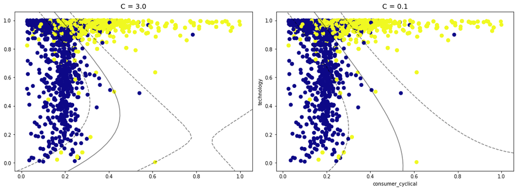

```python
#code privded by https://jakevdp.github.io/PythonDataScienceHandbook/05.07-support-vector-machines.html
fig, ax = plt.subplots(1, 2, figsize=(16, 6))
fig.subplots_adjust(left=0.0625, right=0.95, wspace=0.1)

for axi, C in zip(ax, [3, 0.1]):
    model = SVC(kernel='rbf', C=C, gamma = 1).fit(x_train, y_train)
    axi.scatter(x_train[:, 0], x_train[:, 1], c=y_train, s=50, cmap='plasma')
    plot_svc_decision_function(model, axi)
    axi.scatter(model.support_vectors_[:, 0],
                model.support_vectors_[:, 1],
                s=300, lw=1, facecolors='none');
    axi.set_title('C = {0:.1f}'.format(C), size=14)
plt.ylabel('technology')
plt.xlabel('consumer_cyclical')
```

```python
print("Metrics for C = 3, kernel = rbf, gamma = 1")
print()
print("Accuracy:", metrics.accuracy_score(y_test, y_pred))
print("Precision:", metrics.precision_score(y_test, y_pred))
print("Recall:", metrics.recall_score(y_test, y_pred))
print('AUC score is:', metrics.roc_auc_score(y_test, y_pred))
```

```
Metrics for C = 3, kernel = rbf, gamma = 1

Accuracy: 0.8525411596277738
Precision: 0.8571428571428571
Recall: 0.9025270758122743
AUC score is: 0.8408395096375859
```

# Extra Analysis

## Cross-Validation with SGDClassifier

```python
from sklearn.model_selection import cross_val_score
from sklearn.linear_model import SGDClassifier
from sklearn.model_selection import cross_val_predict
sgd_clf = SGDClassifier(random_state=42)
sgd_clf.fit(X_train, Y_train)
```

```
SGDClassifier(alpha=0.0001, average=False, class_weight=None,
              early_stopping=False, epsilon=0.1, eta0=0.0, fit_intercept=True,
              l1_ratio=0.15, learning_rate='optimal', loss='hinge',
              max_iter=1000, n_iter_no_change=5, n_jobs=None, penalty='l2',
              power_t=0.5, random_state=42, shuffle=True, tol=0.001,
              validation_fraction=0.1, verbose=0, warm_start=False)
```

```python
cross_val_score(sgd_clf, X_train, Y_train, cv=3, scoring="accuracy")
```

```
array([0.86905633, 0.86466715, 0.86310395])
```

### ROC Score

```python
y_scores = cross_val_predict(sgd_clf, X_train, Y_train.iloc[:,0], cv=3, method="decision_function")
```

```python
from sklearn.metrics import roc_curve
fpr, tpr, thresholds = roc_curve(Y_train, y_scores)
```

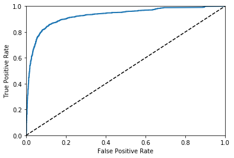

```python
def plot_roc_curve(fpr, tpr, label=None):
    plt.plot(fpr, tpr, linewidth=2, label=label)
    plt.plot([0, 1], [0, 1], 'k--')
    plt.axis([0, 1, 0, 1])
    plt.xlabel('False Positive Rate')
    plt.ylabel('True Positive Rate')
plot_roc_curve(fpr, tpr)
plt.show()
```

```python
from sklearn.metrics import roc_auc_score
#note auc is the Area Under the Curve We want to be close to 1 where 0.5 means more random
roc_auc_score(Y_train, y_scores)
```

```
0.9263757972756754
```

## Confusion Matrix

```python
from sklearn.metrics import confusion_matrix
from sklearn.model_selection import cross_val_predict, cross_val_score
from sklearn import preprocessing
import sklearn.metrics as met
```

```python
y_train_pred = cross_val_predict(sgd_clf, X_train, Y_train, cv=3)
```

```python
confusion_matrix(Y_train, y_train_pred)
```

```
array([[1895,  163],
       [ 388, 1654]], dtype=int64)
```

```python
y_pred = sgd_clf.predict(X_test)
```

```python
print("SGDClassifier Metrics")
print()
print("Accuracy score is:", met.accuracy_score(Y_test, y_pred))
print('Precision score is:', met.precision_score(Y_test, y_pred))
print('Recall score is:', met.recall_score(Y_test, y_pred))
print('AUC score is:', met.roc_auc_score(Y_test, y_pred))
```

```
SGDClassifier Metrics

Accuracy score is: 0.8498293515358362
Precision score is: 0.9006622516556292
Recall score is: 0.7825086306098964
AUC score is: 0.8490720880833509
```

When running a stochastic gradient descent classifier, the various metrics are very similar to SVM

## Random Forest

See what features play significant importance

```python
from sklearn.ensemble import RandomForestClassifier as  RFC
```

```python
forest = RFC(n_jobs=5, n_estimators=20, random_state =0)
```

```python
forest.fit(X_train,Y_train)
```

```
RandomForestClassifier(bootstrap=True, class_weight=None, criterion='gini',
                       max_depth=None, max_features='auto', max_leaf_nodes=None,
                       min_impurity_decrease=0.0, min_impurity_split=None,
                       min_samples_leaf=1, min_samples_split=2,
                       min_weight_fraction_leaf=0.0, n_estimators=20, n_jobs=5,
                       oob_score=False, random_state=0, verbose=0,
                       warm_start=False)
```

```python
y_pred = forest.predict(X_test)
```

```python
print("Random Forest Ensemble Metrics")
print()
print("Accuracy score is:", met.accuracy_score(Y_test, y_pred))
print('Precision score is:', met.precision_score(Y_test, y_pred))
print('Recall score is:', met.recall_score(Y_test, y_pred))
print('AUC score is:', met.roc_auc_score(Y_test, y_pred))
```

```
Random Forest Ensemble Metrics

Accuracy score is: 0.9254835039817975
Precision score is: 0.91
Recall score is: 0.9424626006904487
AUC score is: 0.9256744949458993
```

```python
importances = forest.feature_importances_
indices = np.argsort(importances)
```

```python
features = df3_scale_df.columns
```

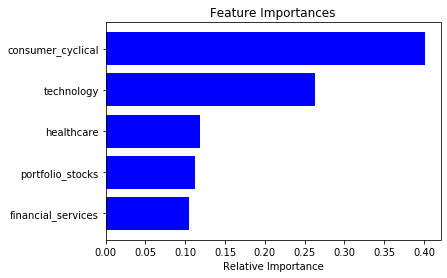

```python
plt.figure(1)
plt.title('Feature Importances')
plt.barh(range(len(indices)), importances[indices], color='b', align='center')
plt.yticks(range(len(indices)), features[indices])
plt.xlabel('Relative Importance')
```

Try to find optimal parameters to use and plot

```python
from sklearn.model_selection import RandomizedSearchCV

# Hyperparameter grid
param_grid = {
    'n_estimators': np.linspace(10, 200).astype(int),
    'max_depth': [None] + list(np.linspace(3, 20).astype(int)),
    'max_features': ['auto', 'sqrt', None] + list(np.arange(0.5, 1, 0.1)),
    'max_leaf_nodes': [None] + list(np.linspace(10, 50, 500).astype(int)),
    'min_samples_split': [2, 5, 10],
    'bootstrap': [True, False]
}

# Estimator for use in random search
estimator = RFC(random_state = 1)

# Create the random search model
rs = RandomizedSearchCV(estimator, param_grid, n_jobs = -1,
                        scoring = 'roc_auc', cv = 3,
                        n_iter = 10, verbose = 1, random_state=1)

# Fit
rs.fit(X_train, Y_train)
```

```
Fitting 3 folds for each of 10 candidates, totalling 30 fits
```

```
[Parallel(n_jobs=-1)]: Using backend LokyBackend with 4 concurrent workers.
[Parallel(n_jobs=-1)]: Done  30 out of  30 | elapsed:   11.0s finished
```

```
RandomizedSearchCV(cv=3, error_score='raise-deprecating',
                   estimator=RandomForestClassifier(bootstrap=True,
                                                    class_weight=None,
                                                    criterion='gini',
                                                    max_depth=None,
                                                    max_features='auto',
                                                    max_leaf_nodes=None,
                                                    min_impurity_decrease=0.0,
                                                    min_impurity_split=None,
                                                    min_samples_leaf=1,
                                                    min_samples_split=2,
                                                    min_weight_fraction_leaf=0.0,
                                                    n_estimators='warn',
                                                    n_jobs=None,
                                                    oob_sc...
                                                           11, 12, 12, 12, 12, ...],
                                        'min_samples_split': [2, 5, 10],
                                        'n_estimators': array([ 10,  13,  17,  21,  25,  29,  33,  37,  41,  44,  48,  52,  56,
        60,  64,  68,  72,  75,  79,  83,  87,  91,  95,  99, 103, 106,
       110, 114, 118, 122, 126, 130, 134, 137, 141, 145, 149, 153, 157,
       161, 165, 168, 172, 176, 180, 184, 188, 192, 196, 200])},
                   pre_dispatch='2*n_jobs', random_state=1, refit=True,
                   return_train_score=False, scoring='roc_auc', verbose=1)
```

```python
rs.best_params_
```

```
{'n_estimators': 106,
 'min_samples_split': 2,
 'max_leaf_nodes': 46,
 'max_features': 0.8999999999999999,
 'max_depth': 15,
 'bootstrap': True}
```

We can see that the best hyperparameter values are not the defaults. We will use best model parms

```python
best_model = rs.best_estimator_
```

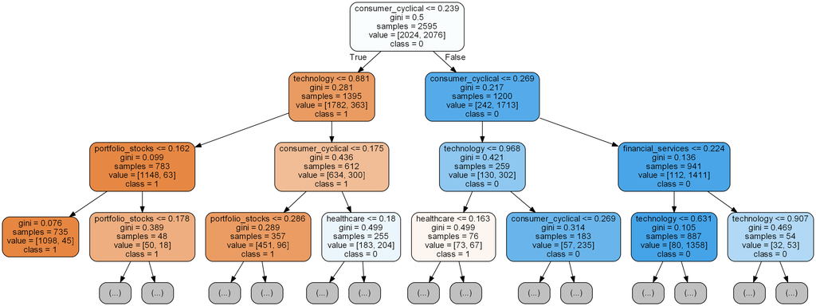

```python
from sklearn.tree import export_graphviz
from subprocess import call
from IPython.display import Image
estimator = best_model.estimators_[1]
import os
os.environ["PATH"] += os.pathsep + r'C:\Users\fcont\Anaconda3\Library\bin\graphviz'
# Export a tree from the forest
export_graphviz(estimator, 'tree_from_optimized_forest.dot', rounded = True,
                feature_names=X_train.columns, max_depth = 3,
                class_names = ['1', '0'], filled = True)
call(['dot', '-Tpng', 'tree_from_optimized_forest.dot', '-o', 'tree_from_optimized_forest.png', '-Gdpi=200'])
Image('tree_from_optimized_forest.png')
```

## K Means Classifier

```python
df3_copy.head()
```

|  | fund_return_3years | technology | portfolio_stocks | investment_Growth | consumer_cyclical | financial_services | size_Large | healthcare | return_binary |
| --- | --- | --- | --- | --- | --- | --- | --- | --- | --- |
| 17112 | 16.90 | 24.49 | 97.60 | 1 | 17.38 | 8.12 | 0 | 16.41 | 1 |
| 9696 | 16.64 | 31.17 | 98.94 | 1 | 16.54 | 6.24 | 0 | 16.53 | 1 |
| 10707 | 16.21 | 35.99 | 98.76 | 1 | 17.04 | 9.55 | 1 | 14.29 | 1 |
| 15038 | 23.69 | 69.68 | 98.49 | 1 | 9.80 | 1.69 | 0 | 12.40 | 1 |
| 22721 | 5.15 | 13.91 | 96.77 | 0 | 4.10 | 23.82 | 1 | 13.64 | 0 |

```python
df3_copy.drop('return_binary', axis=1, inplace=True)
```

```python
from sklearn.cluster import KMeans
```

```python
kmeans = KMeans(n_clusters = 3, random_state = 0)
kmeans.fit(df3_copy)
```

```
KMeans(algorithm='auto', copy_x=True, init='k-means++', max_iter=300,
       n_clusters=3, n_init=10, n_jobs=None, precompute_distances='auto',
       random_state=0, tol=0.0001, verbose=0)
```

```python
print(kmeans.cluster_centers_)
```

```
[[ 3.59192168  1.77845173  2.87265027  0.10928962  2.1758561   2.30434426
   0.24408015  1.37664845]
 [13.59639163 25.43389945 96.32691845  0.65888862 14.01159009 13.50545826
   0.65311523 13.64636998]
 [ 7.03016584 16.5874461  53.27013267  0.15091211 11.08533997 15.88320066
   0.88391376 11.48618574]]
```

```python
df3_copy['clusters'] = kmeans.labels_
```

```python
df3_copy.groupby('clusters').mean()
```

| clusters | fund_return_3years | technology | portfolio_stocks | investment_Growth | consumer_cyclical | financial_services | size_Large | healthcare |
| --- | --- | --- | --- | --- | --- | --- | --- | --- |
| 0 | 3.591922 | 1.778452 | 2.872650 | 0.109290 | 2.175856 | 2.304344 | 0.244080 | 1.376648 |
| 1 | 13.596392 | 25.433899 | 96.326918 | 0.658889 | 14.011590 | 13.505458 | 0.653115 | 13.646370 |
| 2 | 7.030166 | 16.587446 | 53.270133 | 0.150912 | 11.085340 | 15.883201 | 0.883914 | 11.486186 |

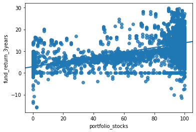

```python
sns.regplot(x='portfolio_stocks', y='fund_return_3years', data=df3_copy)
```

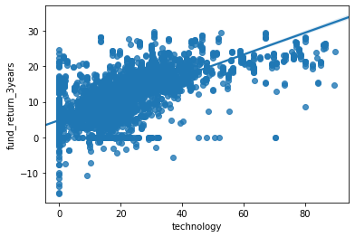

```python
sns.regplot(x='technology', y='fund_return_3years', data=df3_copy)
```

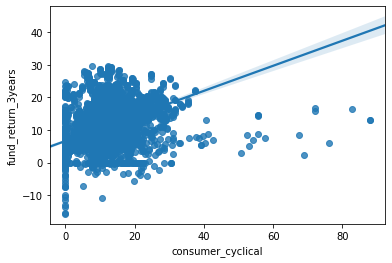

```python
sns.regplot(x='consumer_cyclical', y='fund_return_3years', data=df3_copy)
```